# Kompakte Rundum-Einführung in R

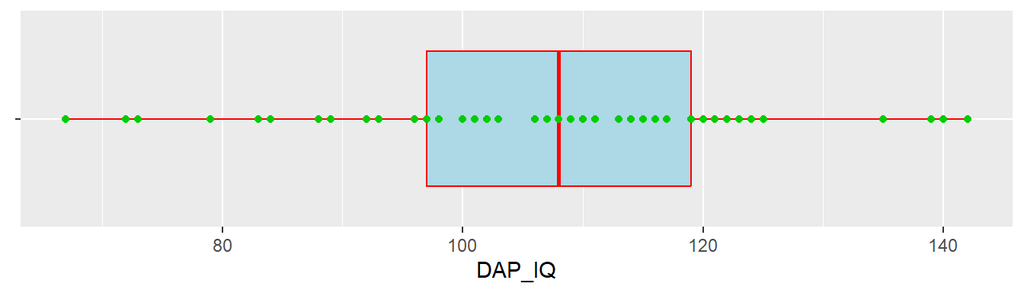

```r
DATA %>%
  ggplot(aes(x = DAP_IQ, y = "")) +
  geom_boxplot(color = "red", fill = "lightblue") +
  geom_point(color = "green3") + # https://r-charts.com/colors/
  ylab(NULL)
```

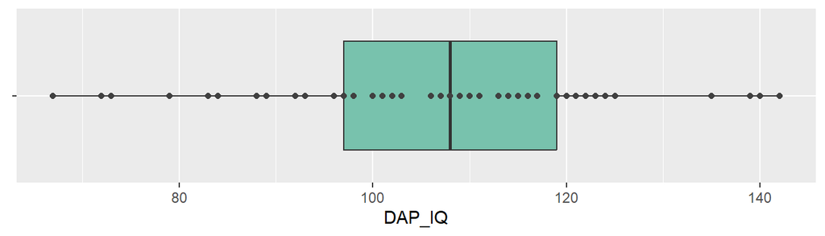

```r
DATA %>%
  ggplot(aes(x = DAP_IQ, y = "")) +
  geom_boxplot(fill = "#78C2AD") + # https://g.co/kgs/XambkJu
  geom_point(color = "gray25") +
  ylab(NULL)
```

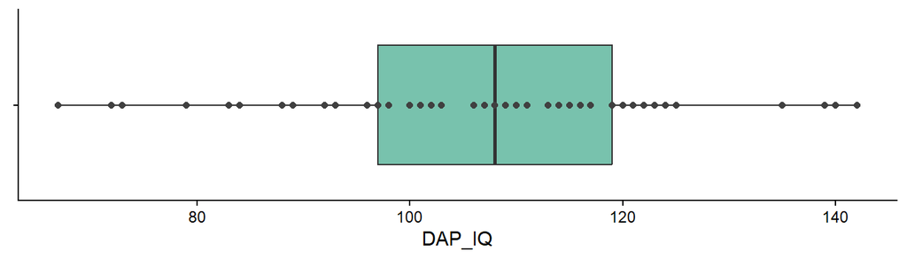

```r
DATA %>%
  ggplot(aes(x = DAP_IQ, y = "")) +
  geom_boxplot(fill = "#78C2AD") +
  geom_point(color = "gray25") +
  ylab(NULL) +
  theme_classic() # https://ggplot2.tidyverse.org/reference/ggtheme.html
```

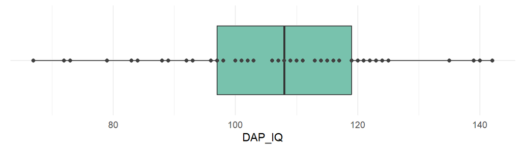

```r
DATA %>%
  ggplot(aes(x = DAP_IQ, y = "")) +
  geom_boxplot(fill = "#78C2AD") +
  geom_point(color = "gray25") +
  ylab(NULL) +
  theme_minimal()
```

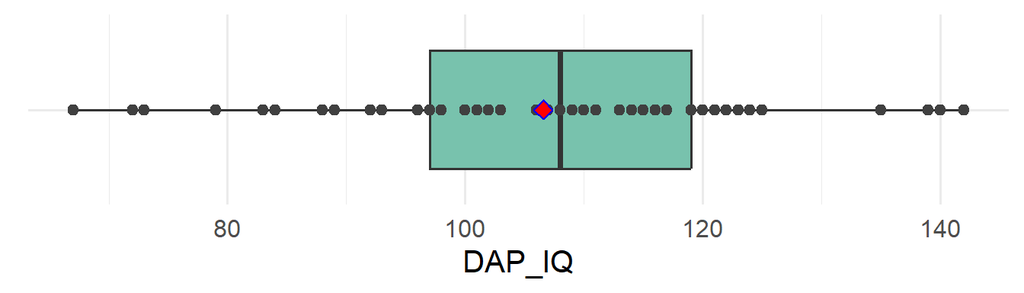

```r
DATA %>%
  ggplot(aes(x = DAP_IQ, y = "")) +
  geom_boxplot(fill = "#78C2AD") +
  geom_point(color = "gray25") +
  stat_summary(fun = mean, geom = "point", color = "blue", fill = "red", shape = 23, size = 3) + # https://www.sthda.com/english/wiki/ggplot2-point-shapes
  ylab(NULL) +
  theme_minimal(base_size = 15)
```

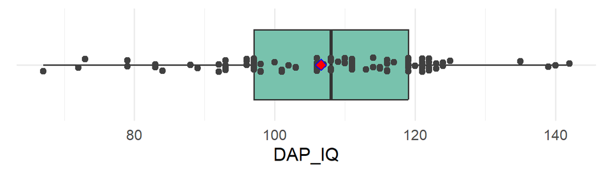

```r
DATA %>%
  ggplot(aes(x = DAP_IQ, y = "")) +
  geom_boxplot(fill = "#78C2AD") +
  geom_jitter(color = "gray25", width = 0, height = 0.075) +
  stat_summary(fun = mean, geom = "point", color = "blue", fill = "red", shape = 23, size = 3) +
  ylab(NULL) +
  theme_minimal(base_size = 15)
```

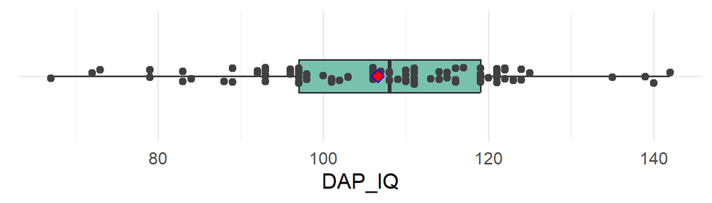

```r
DATA %>%
  ggplot(aes(x = DAP_IQ, y = "")) +
  geom_boxplot(fill = "#78C2AD", width = 0.3) +
  geom_jitter(color = "gray25", width = 0, height = 0.075) +
  stat_summary(fun = mean, geom = "point", color = "blue", fill = "red", shape = 23, size = 3) +
  ylab(NULL) +
  theme_minimal(base_size = 15)
```

**Boxplot-Dokumentation**: https://ggplot2.tidyverse.org/reference/geom_boxplot.html

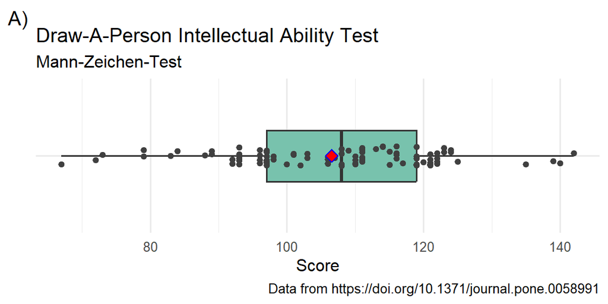

```r
DATA %>%
  ggplot(aes(x = DAP_IQ, y = "")) +
  geom_boxplot(fill = "#78C2AD", width = 0.4) +
  geom_jitter(color = "gray25", width = 0, height = 0.075) +
  stat_summary(fun = mean, geom = "point", color = "blue", fill = "red", shape = 23, size = 3) +
  ylab(NULL) +
  theme_minimal(base_size = 12) +
  xlab("Score") +
  labs(
    title = "Draw-A-Person Intellectual Ability Test",
    subtitle = "Mann-Zeichen-Test",
    caption = "Data from https://doi.org/10.1371/journal.pone.0058991",
    tag = "A)"
  )
```

```r
DATA %>%
  summarise(
    Min = min(DAP_IQ),
    M = mean(DAP_IQ),
    Md = median(DAP_IQ),
    Max = max(DAP_IQ),
    SD = sd(DAP_IQ),
    n = n()
            ) %>%
  round(2) %>%
  gt() %>%
  tab_options(table.align = "left", table.width = pct(45)) %>%
  tab_header("Descriptive Statistics", "Draw-A-Person Intellectual Ability Test")
```

Descriptive Statistics

Draw-A-Person Intellectual Ability Test

| Min | M | Md | Max | SD | n |
| --- | --- | --- | --- | --- | --- |
| 67 | 106.56 | 108 | 142 | 14.65 | 100 |

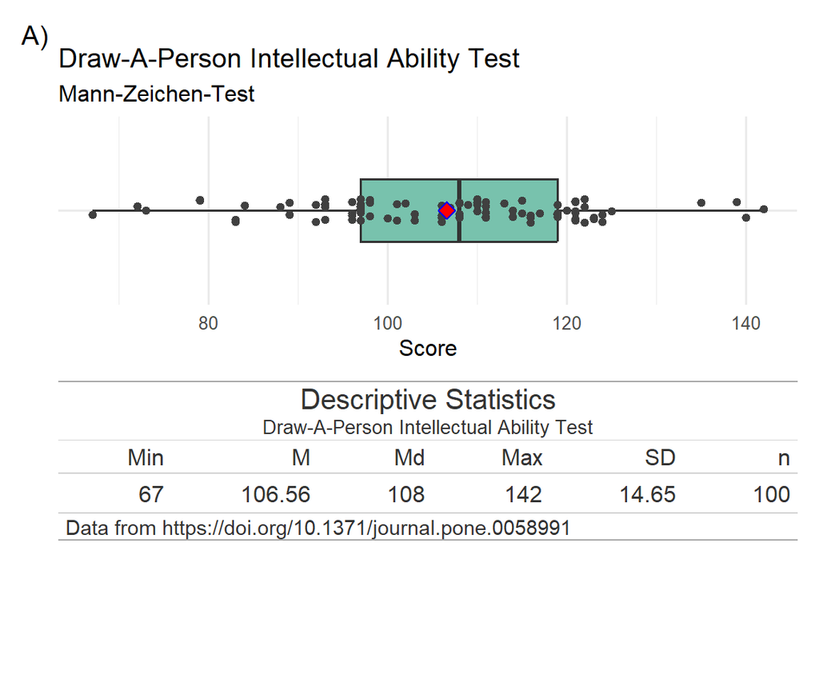

```r
library(patchwork) # https://patchwork.data-imaginist.com/

BOXPLOT <-
  DATA %>%
  ggplot(aes(x = DAP_IQ, y = "")) +
  geom_boxplot(fill = "#78C2AD", width = 0.4) +
  geom_jitter(color = "gray25", width = 0, height = 0.075) +
  stat_summary(fun = mean, geom = "point", color = "blue", fill = "red", shape = 23, size = 3) +
  ylab(NULL) +
  theme_minimal(base_size = 12) +
  xlab("Score") +
  labs(
    title = "Draw-A-Person Intellectual Ability Test",
    subtitle = "Mann-Zeichen-Test",
    tag = "A)"
  )

TABLE <-
  DATA %>%
  summarise(
    Min = min(DAP_IQ),
    M = mean(DAP_IQ),
    Md = median(DAP_IQ),
    Max = max(DAP_IQ),
    SD = sd(DAP_IQ),
    n = n()
            ) %>%
  round(2) %>%
  gt() %>%
  tab_options(table.align = "left", table.width = px(520)) %>%
  tab_header("Descriptive Statistics", "Draw-A-Person Intellectual Ability Test") %>%
  tab_footnote("Data from https://doi.org/10.1371/journal.pone.0058991")

BOXPLOT / TABLE # Boxplot und Tabelle untereinander anzeigen
```

**Wichtig**Übung (Boxplot)**

**Erstellen Sie einen Boxplot für `WPPSI`. Wählen Sie sinnvolle Beschriftungen/Überschriften. Ändern Sie die Farbe der Box und des Mittelwertes. Wählen Sie eine andere Darstellungsform für den Mittelwert (`shape`)**

**Verbinden Sie den Boxplot mit einem Violinplot:**

- https://en.wikipedia.org/wiki/Violin_plot
- https://ggplot2.tidyverse.org/reference/geom_violin.html

**Wichtig**Lösung**

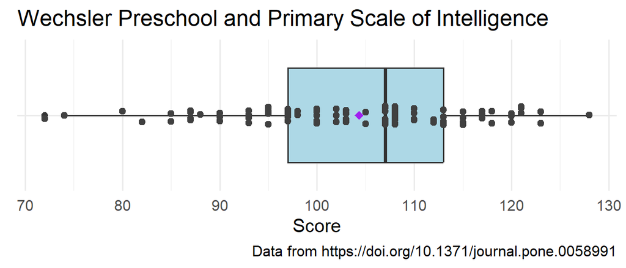

```r
DATA %>%
  ggplot(aes(x = WPPSI, y = "")) +
  geom_boxplot(fill = "lightblue") +
  geom_jitter(color = "gray25", width = 0, height = 0.075) +
  stat_summary(fun = mean, geom = "point", color = "purple", shape = 18, size = 3) +
  ylab(NULL) +
  theme_minimal(base_size = 15) +
  ggtitle("Wechsler Preschool and Primary Scale of Intelligence") +
  xlab("Score") +
  labs(caption = "Data from https://doi.org/10.1371/journal.pone.0058991")
```

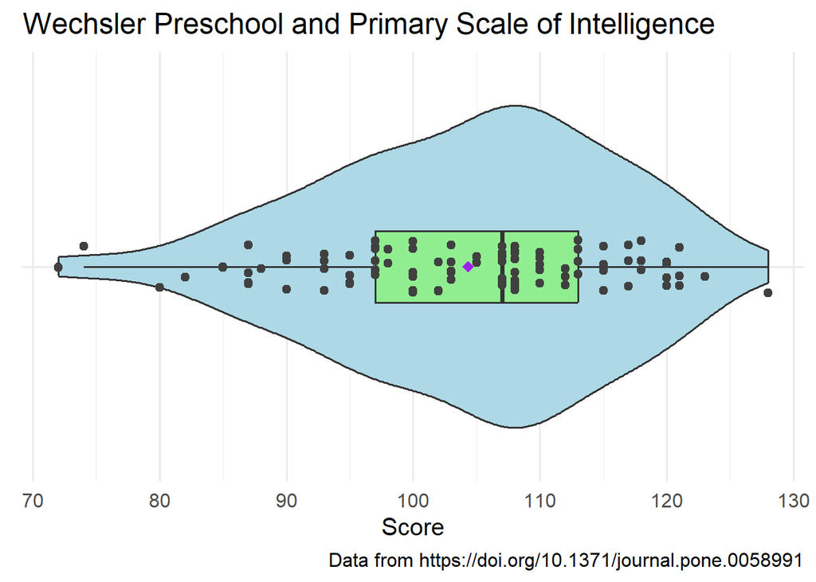

```r
DATA %>%
  ggplot(aes(x = WPPSI, y = "")) +
  geom_violin(fill = "lightblue") +
  geom_boxplot(fill = "lightgreen", width = 0.2) +
  geom_jitter(color = "gray25", width = 0, height = 0.075) +
  stat_summary(fun = mean, geom = "point", color = "purple", shape = 18, size = 3) +
  ylab(NULL) +
  theme_minimal(base_size = 15) +
  ggtitle("Wechsler Preschool and Primary Scale of Intelligence") +
  xlab("Score") +
  labs(caption = "Data from https://doi.org/10.1371/journal.pone.0058991")
```

## Raincloud Plot

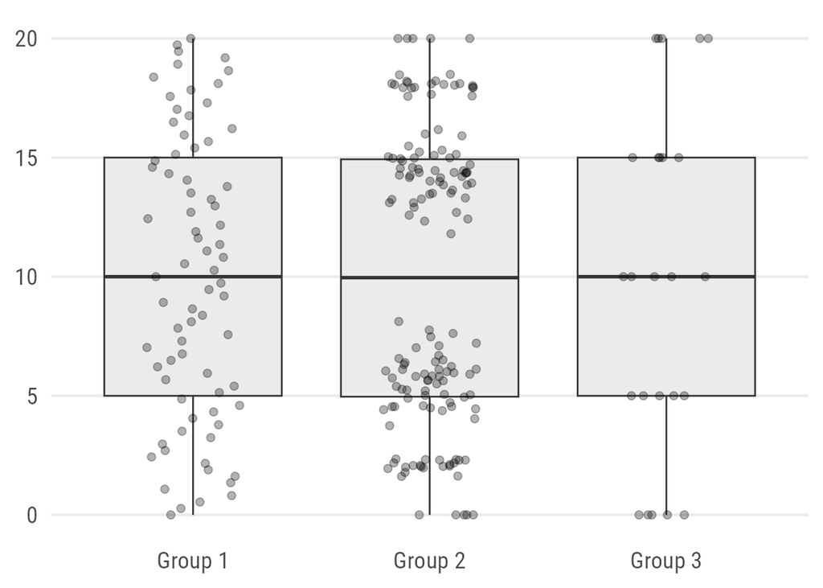

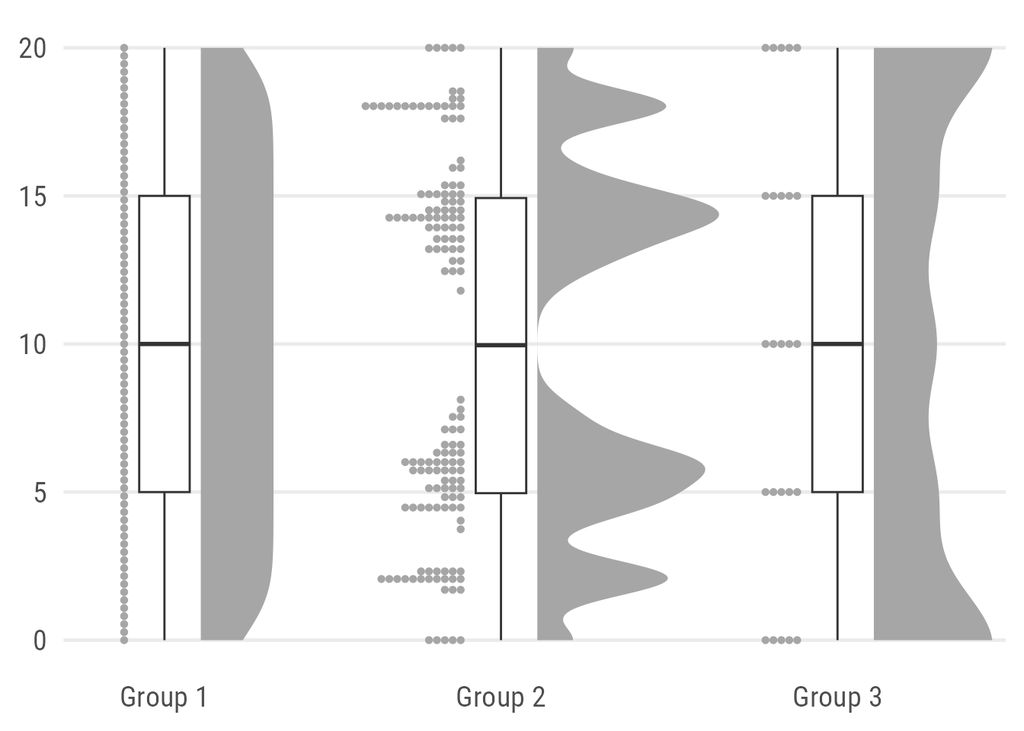

[figure not shown]

Quelle: https://www.cedricscherer.com/2021/06/06/visualizing-distributions-with-raincloud-plots-and-how-to-create-them-with-ggplot2/

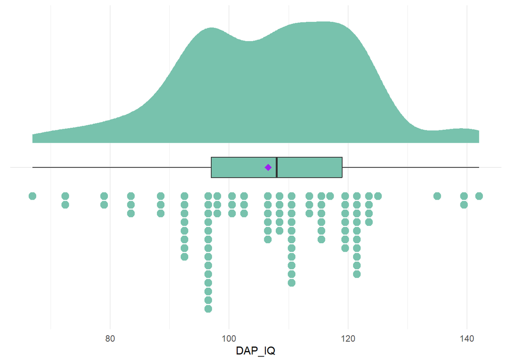

```r
library(ggdist) # https://mjskay.github.io/ggdist/

DATA %>%
  ggplot(aes(x = DAP_IQ, y = "")) +
  stat_slab(justification = -.2, fill = "#78C2AD") +
  geom_boxplot(width = .15, fill = "#78C2AD") +
  stat_summary(fun = mean, geom = "point", color = "purple", shape = 18, size = 3) +
  stat_dots(side = "left", justification = 1.2, color = "#78C2AD", fill = "#78C2AD") +
  ylab(NULL) +
  theme_minimal()
```

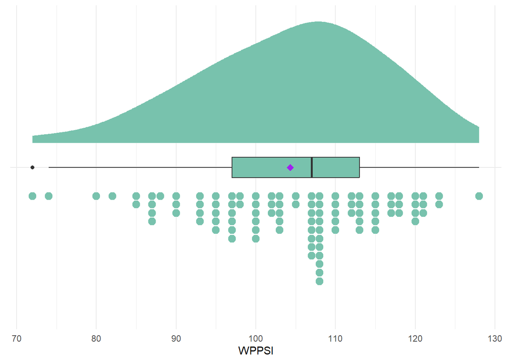

```r
DATA %>%
  ggplot(aes(x = WPPSI, y = "")) +
  stat_slab(justification = -.2, fill = "#78C2AD") +
  geom_boxplot(width = .15, fill = "#78C2AD") +
  stat_summary(fun = mean, geom = "point", color = "purple", shape = 18, size = 3) +
  stat_dots(side = "left", justification = 1.2, color = "#78C2AD", fill = "#78C2AD") +
  ylab(NULL) +
  theme_minimal()
```

**TippWeiterführende Links zum Thema Visualisierung (mit ggplot2)**

- https://ggplot2.tidyverse.org/
- https://r-charts.com/
- https://r-graph-gallery.com/
- https://ggplot2-book.org/
- https://r-graphics.org/
- https://r4ds.hadley.nz/visualize.html

# Datenmanagement

## Transformieren, auswählen und filtern (mutate, select und filter)

```r
NAME <-
  c("Susi", "Ali", "Klaus", "Oleg", "Rudi")

AUGENFARBE <-
  c("Blaugrau", "Braun", "Grün", "Grün", "Grau")

GEWICHT_IN_KG <-
  c(84, 65, 72, 66, 70)

GROESSE_IN_M <-
  c(1.80, 1.65, 1.75, 1.63, 2.10)

ANZAHL_HAUSTIERE <-
  c(2, 0, 0, 1, 0)

DATA_2 <-
  data.frame(NAME,
             AUGENFARBE,
             GEWICHT_IN_KG,
             GROESSE_IN_M,
             ANZAHL_HAUSTIERE)

DATA_2 %>%
  gt()
```

| NAME | AUGENFARBE | GEWICHT_IN_KG | GROESSE_IN_M | ANZAHL_HAUSTIERE |
| --- | --- | --- | --- | --- |
| Susi | Blaugrau | 84 | 1.80 | 2 |
| Ali | Braun | 65 | 1.65 | 0 |
| Klaus | Grün | 72 | 1.75 | 0 |
| Oleg | Grün | 66 | 1.63 | 1 |
| Rudi | Grau | 70 | 2.10 | 0 |

```r
DATA_2$BMI <-
  DATA_2$GEWICHT_IN_KG / DATA_2$GROESSE_IN_M^2 # BMI-Berechnung

DATA_2 %>%
  gt()
```

| NAME | AUGENFARBE | GEWICHT_IN_KG | GROESSE_IN_M | ANZAHL_HAUSTIERE | BMI |
| --- | --- | --- | --- | --- | --- |
| Susi | Blaugrau | 84 | 1.80 | 2 | 25.92593 |
| Ali | Braun | 65 | 1.65 | 0 | 23.87511 |
| Klaus | Grün | 72 | 1.75 | 0 | 23.51020 |
| Oleg | Grün | 66 | 1.63 | 1 | 24.84098 |
| Rudi | Grau | 70 | 2.10 | 0 | 15.87302 |

```r
DATA_2 %>%
  mutate(bmi = GEWICHT_IN_KG / GROESSE_IN_M^2) %>% # BMI-Berechnung
  gt()
```

| NAME | AUGENFARBE | GEWICHT_IN_KG | GROESSE_IN_M | ANZAHL_HAUSTIERE | BMI | bmi |
| --- | --- | --- | --- | --- | --- | --- |
| Susi | Blaugrau | 84 | 1.80 | 2 | 25.92593 | 25.92593 |
| Ali | Braun | 65 | 1.65 | 0 | 23.87511 | 23.87511 |
| Klaus | Grün | 72 | 1.75 | 0 | 23.51020 | 23.51020 |
| Oleg | Grün | 66 | 1.63 | 1 | 24.84098 | 24.84098 |
| Rudi | Grau | 70 | 2.10 | 0 | 15.87302 | 15.87302 |

```r
DATA_2 %>%
  gt()
```

| NAME | AUGENFARBE | GEWICHT_IN_KG | GROESSE_IN_M | ANZAHL_HAUSTIERE | BMI |
| --- | --- | --- | --- | --- | --- |
| Susi | Blaugrau | 84 | 1.80 | 2 | 25.92593 |
| Ali | Braun | 65 | 1.65 | 0 | 23.87511 |
| Klaus | Grün | 72 | 1.75 | 0 | 23.51020 |
| Oleg | Grün | 66 | 1.63 | 1 | 24.84098 |
| Rudi | Grau | 70 | 2.10 | 0 | 15.87302 |

```r
DATA_2 <-
  DATA_2 %>%
  mutate(bmi = GEWICHT_IN_KG / GROESSE_IN_M^2)

DATA_2 %>%
  gt()
```

| NAME | AUGENFARBE | GEWICHT_IN_KG | GROESSE_IN_M | ANZAHL_HAUSTIERE | BMI | bmi |
| --- | --- | --- | --- | --- | --- | --- |
| Susi | Blaugrau | 84 | 1.80 | 2 | 25.92593 | 25.92593 |
| Ali | Braun | 65 | 1.65 | 0 | 23.87511 | 23.87511 |
| Klaus | Grün | 72 | 1.75 | 0 | 23.51020 | 23.51020 |
| Oleg | Grün | 66 | 1.63 | 1 | 24.84098 | 24.84098 |
| Rudi | Grau | 70 | 2.10 | 0 | 15.87302 | 15.87302 |

```r
DATA_2[c(2,4), c("NAME", "GEWICHT_IN_KG")] %>%
  gt()
```

| NAME | GEWICHT_IN_KG |
| --- | --- |
| Ali | 65 |
| Oleg | 66 |

```r
DATA_2 %>%
  slice(2, 4) %>%
  select(NAME, GEWICHT_IN_KG) %>%
  gt()
```

| NAME | GEWICHT_IN_KG |
| --- | --- |
| Ali | 65 |
| Oleg | 66 |

```r
DATA_KEINE_HAUSTIERE <-
  DATA_2 %>%
  filter(ANZAHL_HAUSTIERE == 0) %>%
  select(NAME, GEWICHT_IN_KG, ANZAHL_HAUSTIERE)

DATA_KEINE_HAUSTIERE %>%
  gt()
```

| NAME | GEWICHT_IN_KG | ANZAHL_HAUSTIERE |
| --- | --- | --- |
| Ali | 65 | 0 |
| Klaus | 72 | 0 |
| Rudi | 70 | 0 |

```r
DATA_HAUSTIERE <-
  DATA_2 %>%
  filter(ANZAHL_HAUSTIERE > 0) %>%
  select(NAME, GEWICHT_IN_KG, ANZAHL_HAUSTIERE, AUGENFARBE)

DATA_HAUSTIERE %>%
  gt()
```

| NAME | GEWICHT_IN_KG | ANZAHL_HAUSTIERE | AUGENFARBE |
| --- | --- | --- | --- |
| Susi | 84 | 2 | Blaugrau |
| Oleg | 66 | 1 | Grün |

```r
DATA_HAUSTIERE <-
  DATA_2 %>%
  filter(ANZAHL_HAUSTIERE > 0 & AUGENFARBE == "Grün") %>%
  select(NAME, GEWICHT_IN_KG, ANZAHL_HAUSTIERE, AUGENFARBE)

DATA_HAUSTIERE %>%
  gt()
```

| NAME | GEWICHT_IN_KG | ANZAHL_HAUSTIERE | AUGENFARBE |
| --- | --- | --- | --- |
| Oleg | 66 | 1 | Grün |

## Logische Operatoren

| Operator | Bedeutung |
| --- | --- |
| `==` | gleich |
| `!=` | ungleich |
| `>` | größer als |
| `<` | kleiner als |
| `>=` | größer-gleich |
| `<=` | kleiner-gleich |
| `&` | und |
| `\|` | oder |

## LLM-Hilfe

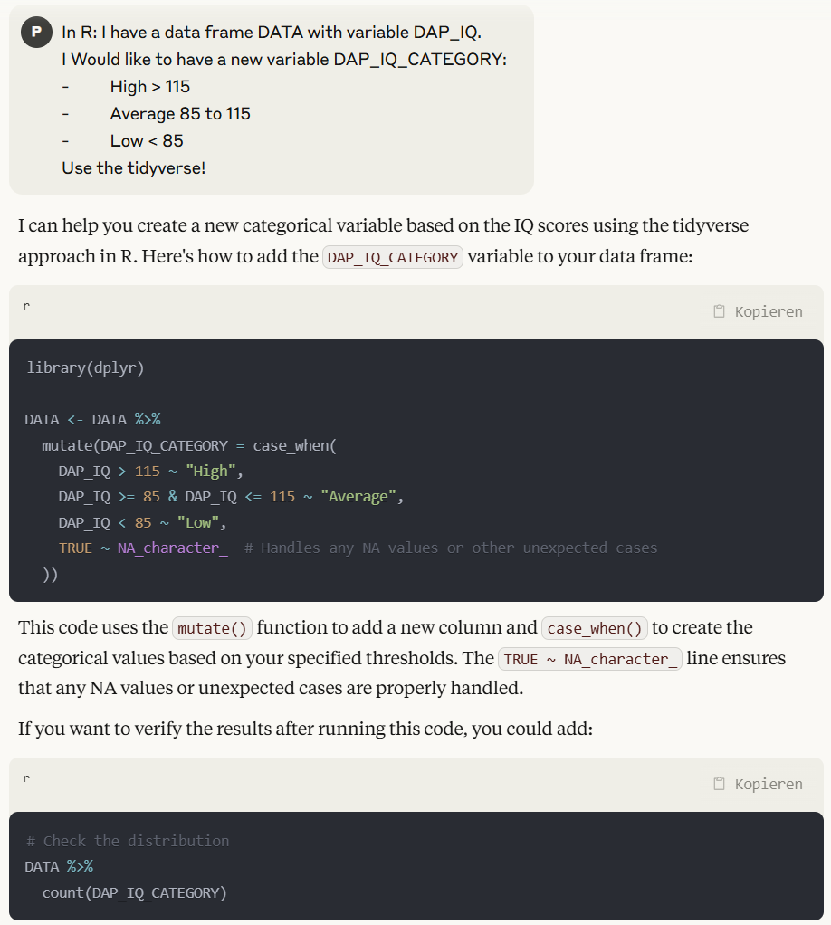

```r
DATA <- DATA %>%
  mutate(DAP_IQ_CATEGORY = case_when(
    DAP_IQ > 115 ~ "High",
    DAP_IQ >= 85 & DAP_IQ <= 115 ~ "Average",
    DAP_IQ < 85 ~ "Low",
    TRUE ~ NA_character_  # Handles any NA values or other unexpected cases
  ))

DATA %>%
  count(DAP_IQ_CATEGORY) %>%
  gt()
```

| DAP_IQ_CATEGORY | n |
| --- | --- |
| Average | 61 |
| High | 31 |
| Low | 8 |

**Wichtig**Übung**

Lassen Sie sich folgende Datensätze anzeigen (`filter()`):

- `DAP_IQ` > 115
- `DAP_IQ` > 115 und `WPPSI` > 115
- Lassen Sie sich Kind A anzeigen

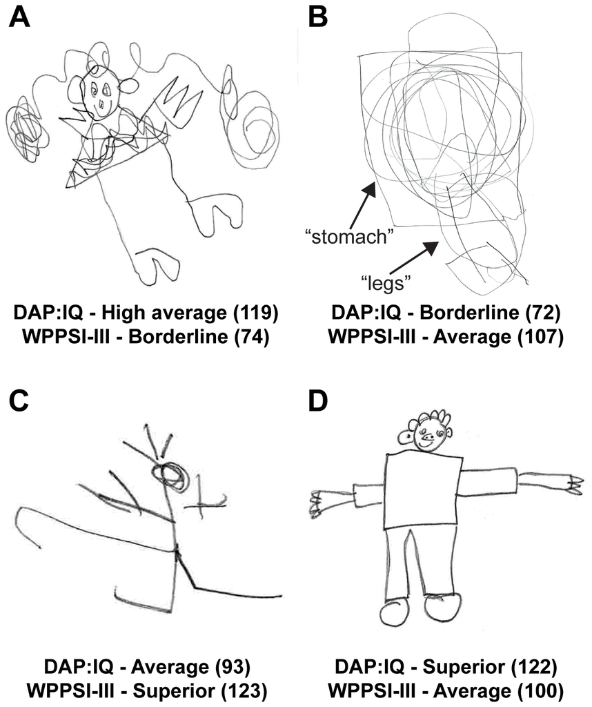

**Wichtig**Lösung**

```r
DATA %>%
  filter(DAP_IQ > 115) %>%
  gt()
```

| Participant | DAP_IQ | WPPSI | DAP_IQ_CATEGORY |
| --- | --- | --- | --- |
| 70 | 116 | 95 | High |
| 71 | 116 | 108 | High |
| 72 | 116 | 110 | High |
| 73 | 116 | 115 | High |
| 74 | 117 | 115 | High |
| 75 | 119 | 74 | High |
| 76 | 119 | 97 | High |
| 77 | 119 | 103 | High |
| 78 | 119 | 108 | High |
| 79 | 119 | 108 | High |
| 80 | 119 | 115 | High |
| 81 | 120 | 120 | High |
| 82 | 121 | 100 | High |
| 83 | 121 | 107 | High |
| 84 | 121 | 107 | High |
| 85 | 121 | 108 | High |
| 86 | 121 | 118 | High |
| 87 | 121 | 118 | High |
| 88 | 122 | 100 | High |
| 89 | 122 | 107 | High |
| 90 | 122 | 108 | High |
| 91 | 122 | 123 | High |
| 92 | 123 | 87 | High |
| 93 | 123 | 121 | High |
| 94 | 124 | 95 | High |
| 95 | 124 | 108 | High |
| 96 | 125 | 121 | High |
| 97 | 135 | 95 | High |
| 98 | 139 | 128 | High |
| 99 | 140 | 108 | High |
| 100 | 142 | 118 | High |

```r
DATA %>%
  filter(DAP_IQ > 115, WPPSI > 115) %>%
  gt()
```

| Participant | DAP_IQ | WPPSI | DAP_IQ_CATEGORY |
| --- | --- | --- | --- |
| 81 | 120 | 120 | High |
| 86 | 121 | 118 | High |
| 87 | 121 | 118 | High |
| 91 | 122 | 123 | High |
| 93 | 123 | 121 | High |
| 96 | 125 | 121 | High |
| 98 | 139 | 128 | High |
| 100 | 142 | 118 | High |

```r
DATA %>%
  filter(DAP_IQ > 115 & WPPSI > 115) %>%
  gt()
```

| Participant | DAP_IQ | WPPSI | DAP_IQ_CATEGORY |
| --- | --- | --- | --- |
| 81 | 120 | 120 | High |
| 86 | 121 | 118 | High |
| 87 | 121 | 118 | High |
| 91 | 122 | 123 | High |
| 93 | 123 | 121 | High |
| 96 | 125 | 121 | High |
| 98 | 139 | 128 | High |
| 100 | 142 | 118 | High |

```r
DATA %>%
  filter(DAP_IQ == 119 & WPPSI == 74)
```

```
# A tibble: 1 × 4
  Participant DAP_IQ WPPSI DAP_IQ_CATEGORY
        <dbl>  <dbl> <dbl> <chr>
1          75    119    74 High
```

```r
DATA %>%
  filter(DAP_IQ != 119 & WPPSI != 74)
```

```
# A tibble: 94 × 4
   Participant DAP_IQ WPPSI DAP_IQ_CATEGORY
         <dbl>  <dbl> <dbl> <chr>
 1           1     67    85 Low
 2           2     72   107 Low
 3           3     73   102 Low
 4           4     79    95 Low
 5           5     79   108 Low
 6           6     83    97 Low
 7           7     83   103 Low
 8           8     84   113 Low
 9           9     88    88 Average
10          10     89    72 Average
# ℹ 84 more rows
```

```r
DATA %>%
  filter(!(DAP_IQ == 119 & WPPSI == 74))
```

```
# A tibble: 99 × 4
   Participant DAP_IQ WPPSI DAP_IQ_CATEGORY
         <dbl>  <dbl> <dbl> <chr>
 1           1     67    85 Low
 2           2     72   107 Low
 3           3     73   102 Low
 4           4     79    95 Low
 5           5     79   108 Low
 6           6     83    97 Low
 7           7     83   103 Low
 8           8     84   113 Low
 9           9     88    88 Average
10          10     89    72 Average
# ℹ 89 more rows
```

**Wichtig**Übung**

- Erstellen Sie eine neue Variable (`mutate()`), die die Differenz zwischen `DAP_IQ` und `WPPSI` anzeigt.
- Welche Kinder haben identische Werte (`DAP_IQ` und `WPPSI`)? Erstellen Sie eine entsprechende Variable (`mutate()`).

**Wichtig**Lösung**

```r
DATA %>%
  mutate(DIFF = DAP_IQ - WPPSI)
```

```
# A tibble: 100 × 5
   Participant DAP_IQ WPPSI DAP_IQ_CATEGORY  DIFF
         <dbl>  <dbl> <dbl> <chr>           <dbl>
 1           1     67    85 Low               -18
 2           2     72   107 Low               -35
 3           3     73   102 Low               -29
 4           4     79    95 Low               -16
 5           5     79   108 Low               -29
 6           6     83    97 Low               -14
 7           7     83   103 Low               -20
 8           8     84   113 Low               -29
 9           9     88    88 Average             0
10          10     89    72 Average            17
# ℹ 90 more rows
```

```r
DATA %>%
  mutate(DIFF = DAP_IQ - WPPSI) %>%
  mutate(GLEICH = DIFF == 0)
```

```
# A tibble: 100 × 6
   Participant DAP_IQ WPPSI DAP_IQ_CATEGORY  DIFF GLEICH
         <dbl>  <dbl> <dbl> <chr>           <dbl> <lgl>
 1           1     67    85 Low               -18 FALSE
 2           2     72   107 Low               -35 FALSE
 3           3     73   102 Low               -29 FALSE
 4           4     79    95 Low               -16 FALSE
 5           5     79   108 Low               -29 FALSE
 6           6     83    97 Low               -14 FALSE
 7           7     83   103 Low               -20 FALSE
 8           8     84   113 Low               -29 FALSE
 9           9     88    88 Average             0 TRUE
10          10     89    72 Average            17 FALSE
# ℹ 90 more rows
```

```r
DATA %>%
  mutate(DIFF = DAP_IQ - WPPSI) %>%
  mutate(GLEICH = case_when(DIFF == 0 ~ "JA",
                            DIFF != 0 ~ "NEIN"))
```

```
# A tibble: 100 × 6
   Participant DAP_IQ WPPSI DAP_IQ_CATEGORY  DIFF GLEICH
         <dbl>  <dbl> <dbl> <chr>           <dbl> <chr>
 1           1     67    85 Low               -18 NEIN
 2           2     72   107 Low               -35 NEIN
 3           3     73   102 Low               -29 NEIN
 4           4     79    95 Low               -16 NEIN
 5           5     79   108 Low               -29 NEIN
 6           6     83    97 Low               -14 NEIN
 7           7     83   103 Low               -20 NEIN
 8           8     84   113 Low               -29 NEIN
 9           9     88    88 Average             0 JA
10          10     89    72 Average            17 NEIN
# ℹ 90 more rows
```

```r
DATA %>%
  mutate(GLEICH = DAP_IQ == WPPSI)
```

```
# A tibble: 100 × 5
   Participant DAP_IQ WPPSI DAP_IQ_CATEGORY GLEICH
         <dbl>  <dbl> <dbl> <chr>           <lgl>
 1           1     67    85 Low             FALSE
 2           2     72   107 Low             FALSE
 3           3     73   102 Low             FALSE
 4           4     79    95 Low             FALSE
 5           5     79   108 Low             FALSE
 6           6     83    97 Low             FALSE
 7           7     83   103 Low             FALSE
 8           8     84   113 Low             FALSE
 9           9     88    88 Average         TRUE
10          10     89    72 Average         FALSE
# ℹ 90 more rows
```

```r
DATA %>%
  mutate(GLEICH = DAP_IQ == WPPSI) %>%
  count(GLEICH) %>%
  gt()
```

| GLEICH | n |
| --- | --- |
| FALSE | 98 |
| TRUE | 2 |

# R Session Info

```r
library(devtools)
```